# Counting Ssd1 motifs in Aspergillus fumigatus, approximate 5’UTRs with fixed length upstream of CDSs

Edward Wallace

07/02/2021

# Summary

We are looking for occurences of the major part of the Ssd1-binding motif, `CNYTCNYT`, in *Aspergillus fumigatus*.

Here we downloaded the 1000nt of genomic sequence upstream of translation start codons from [fungidb](https://fungidb.org/).

The major finding is that this motif is comparatively rare in *A. fumigatus* upstream sequences, and genes with the motif are enriched in cell wall proteins. This is what we expected.

# Load approximate 1000nt UTRs

```r
# define fasta filename
Af_up1000_file <- paste(here::here(),
                        "motif_conservation",
                        "data",
                        "Afumigatus_Af293_ATG_upstream_1000nt.fasta",
                        sep= "/")

# load fasta file as DNA string set
Af_up1000_DSS <- readDNAStringSet(Af_up1000_file)

# remove truncated sequences, which we don't need.
Af_up1000_DSS <- Af_up1000_DSS[width(Af_up1000_DSS) == 1000]

# assign just the ORF id to the name, but keep all the info.
Af_namesinfo <-
    tibble(everything = names(Af_up1000_DSS)) %>%
    tidyr::separate(everything,into = c("id","strain","info","seqtype","seq","length"), sep = " \\| ") %>%
    dplyr::select(id, info,seq)

names(Af_up1000_DSS) <- Af_namesinfo$id

# print the DNA string set to check it came out ok
Af_up1000_DSS
```

```
## DNAStringSet object of length 10128:
##         width seq                                           names
##     [1]  1000 AAATGAAGAGATGGACCAGTT...ATCCCGTCATCGCCGTTGAGG Afu8g05820
##     [2]  1000 CACGGAAAGCCCGCTGCCTTC...TTCTCTTCTTGCTGCCAAGGA Afu3g04030
##     [3]  1000 TCAACTTACTGTACGTTGTCA...CGGATTCAGAACATAGCCACC Afu2g15312
##     [4]  1000 AAGACTCACAATCGGGTTTTG...ATGGCAGATGATAATAGGTAG Afu2g12330
##     [5]  1000 TATACCCAAGGCGCGGCTGGA...TCTCTGGCACTACGAGAAGAC Afu5g02650
##     ...   ... ...
## [10124]  1000 AGTTTCCCTGCTCGGCACCCA...AGAAGCAGTGTAGCCAGAATC Afu2g11350
## [10125]  1000 GCACAGGATGCCGGCGTGGAC...ATTGATCGTGGCCGTATCACC Afu2g08260
## [10126]  1000 AATGGCTCCTTTCTCGTAGAC...CACTAACGGAGACTTCCTGCA Afu6g01930
## [10127]  1000 AAGGGCGCTTCCGACATTCCC...AATCTCTAACCTTCATCTAAC Afu6g06700
## [10128]  1000 TGGATCATGTAGACAACAGAG...CACAGACTTTCAACGATCAAG Afu5g13780
```

# Count occurences of Ssd1 motif CNYTCNYT

We use functions from Biostrings (bioconductor) to find motif instances. This was inspired by [a blogpost from kasper daniel hansen](https://kasperdanielhansen.github.io/genbioconductor/html/Biostrings_Matching.html).

We use `fixed = "subject"` to allow ambiguous characters in the pattern `CNYTCNYT`, but not in the sequence being searched.

We put all the relevant counts into a tibble for easier post-processing.

```r
CNYTCNYT_count_df <- tibble(id = Af_namesinfo$id,
                            info = Af_namesinfo$info,
                            count_up1000 = vcountPattern(pattern = DNAString("CNYTCNYT"),
                                 subject = Af_up1000_DSS,
                                 fixed = "subject"),
                            count_up200 = vcountPattern(pattern = DNAString("CNYTCNYT"),
                                 subject = subseq(Af_up1000_DSS,start = 801L, end = 1000L),
                                 fixed = "subject"),
                            count_up100 = vcountPattern(pattern = DNAString("CNYTCNYT"),
                                 subject = subseq(Af_up1000_DSS,start = 901L, end = 1000L),
                                 fixed = "subject")
)

summary(CNYTCNYT_count_df)
```

```
##       id                info            count_up1000     count_up200
##  Length:10128       Length:10128       Min.   : 0.000   Min.   : 0.0000
##  Class :character   Class :character   1st Qu.: 0.000   1st Qu.: 0.0000
##  Mode  :character   Mode  :character   Median : 1.000   Median : 0.0000
##                                        Mean   : 1.717   Mean   : 0.5327
##                                        3rd Qu.: 2.000   3rd Qu.: 1.0000
##                                        Max.   :22.000   Max.   :19.0000
##   count_up100
##  Min.   : 0.00
##  1st Qu.: 0.00
##  Median : 0.00
##  Mean   : 0.28
##  3rd Qu.: 0.00
##  Max.   :11.00
```

## Which genes have highest counts?

```r
arrange(CNYTCNYT_count_df,desc(count_up100)) %>%
    head(n = 20) %>%
    knitr::kable()
```

| id | info | count_up1000 | count_up200 | count_up100 |
| --- | --- | --- | --- | --- |
| Afu2g03490 | Putative calcium/calmodulin-dependent protein kinase | 12 | 11 | 11 |
| Afu6g04580 | Ortholog of A. nidulans FGSC A4 : AN6562, A. niger CBS 513.88 : An15g00740, A. oryzae RIB40 : AO090701000088, Aspergillus wentii : Aspwe1_0036108 and Aspergillus sydowii : Aspsy1_0051771 | 11 | 10 | 10 |
| Afu5g10380 | Putative pectin lyase | 9 | 9 | 9 |
| Afu4g13920 | Ortholog(s) have polygalacturonase activity, role in pectin catabolic process and extracellular region localization | 7 | 7 | 7 |
| Afu8g06830 | Putative endo-1,4 beta-glucanase, a predicted secreted hydrolase with a fungal cellulose binding domain | 9 | 7 | 7 |
| Afu3g01650 | Ortholog of A. nidulans FGSC A4 : AN7870, A. fumigatus Af293 : Afu6g11970, Neosartorya fischeri NRRL 181 : NFIA_002730, NFIA_057640 and Aspergillus versicolor : Aspve1_0204208 | 6 | 6 | 6 |
| Afu5g10790 | Ortholog(s) have endoplasmic reticulum, nuclear envelope localization | 6 | 6 | 6 |
| Afu5g08180 | protein of unknown function | 7 | 7 | 6 |
| Afu1g10630 | Putative S-adenosylmethionine synthetase | 6 | 6 | 6 |
| Afu6g09540 | Putative endo-1,4 beta-glucanase, a predicted secreted hydrolase with a fungal cellulose binding domain | 7 | 6 | 6 |
| Afu4g00890 | Ortholog of Neosartorya fischeri NRRL 181 : NFIA_044610, Aspergillus fumigatus A1163 : AFUB_101390 and Aspergillus clavatus NRRL 1 : ACLA_078150 | 7 | 6 | 6 |
| Afu4g01350 | G-protein coupled receptor | 5 | 5 | 5 |
| Afu5g11890 | Ortholog(s) have Rho guanyl-nucleotide exchange factor activity, role in actomyosin contractile ring assembly, regulation of actomyosin contractile ring contraction and contractile ring localization | 20 | 10 | 5 |
| Afu7g04580 | Putative TBC domain protein with a predicted role in the regulation of plasma membrane and endosome trafficking | 16 | 7 | 5 |
| Afu2g11760 | Ortholog(s) have deubiquitinase activator activity | 6 | 5 | 5 |
| Afu3g10065 | Ortholog of A. nidulans FGSC A4 : AN4982, A. niger CBS 513.88 : An16g03820, A. oryzae RIB40 : AO090003000540, Neosartorya fischeri NRRL 181 : NFIA_067230 and Aspergillus wentii : Aspwe1_0049188 | 7 | 6 | 5 |
| Afu2g16090 | Karyopherin alpha subunit | 5 | 5 | 5 |
| Afu3g07410 | Putative isoamyl alcohol oxidase | 5 | 4 | 4 |
| Afu1g03352 | Has domain(s) with predicted hydrolase activity | 4 | 4 | 4 |
| Afu2g12000 | Ortholog of A. nidulans FGSC A4 : AN10790, A. niger CBS 513.88 : An02g04060, A. oryzae RIB40 : AO090026000447, Aspergillus sydowii : Aspsy1_0031545 and Aspergillus carbonarius ITEM 5010 : Acar5010_203… | 5 | 5 | 4 |

## 1000nt upstream

Results from all 1000nt upstream.

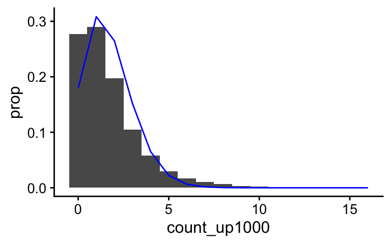

```r
CNYT_up1000_reducedmean <- CNYTCNYT_count_df %>%
    pull(count_up1000) %>%
    mean()

CNYT_up1000_reducedvar <- CNYTCNYT_count_df %>%
    pull(count_up1000) %>%
    var()

ggplot(data = CNYTCNYT_count_df, aes(x = count_up1000)) +
    geom_bar(width = 1, aes(y = ..prop..), stat = "count", group = 1) +
    geom_line(data = tibble(),
              aes(x = 0:20, y = dpois(0:20,lambda=CNYT_up1000_reducedmean)),
              colour = "blue") +
    scale_x_continuous(limits = c(-0.5,16), oob = scales::squish)
```

This count is overdispersed relative to a Poisson distribution, with mean 1.7171209, variance 3.6435816.

## 100nt upstream

Results filtered to only the 100nt closest to the start codon.

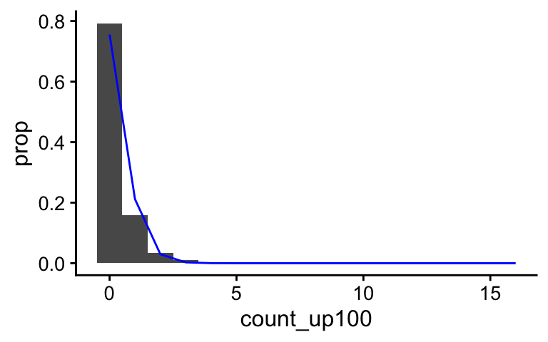

```r
CNYT_up100_reducedmean <- CNYTCNYT_count_df %>%
    pull(count_up100) %>%
    mean()

CNYT_up100_reducedvar <- CNYTCNYT_count_df %>%
    pull(count_up100) %>%
    var()

ggplot(data = CNYTCNYT_count_df, aes(x = count_up100)) +
    geom_bar(width = 1, aes(y = ..prop..), stat = "count", group = 1) +
    geom_line(data = tibble(),
              aes(x = 0:20, y = dpois(0:20,lambda=CNYT_up100_reducedmean)),
              colour = "blue") +
    scale_x_continuous(limits = c(-0.5,16), oob = scales::squish)
```

This count is slightly overdispersed relative to a Poisson distribution, with mean 0.2800158, variance 0.4295325.

# Write list of genes for GO search, based on counts 100nt upstream

```r
id_file_CNYTCNYT1_up100 <- paste(here::here(),
                                 "motif_conservation",
                                 "results",
                                 "Af_id_list_CNYTCNYT1_up100.txt",
                                 sep = "/")

CNYTCNYT_count_df %>%
    filter(count_up100 >= 1) %>%
    pull(id) %>%
    write_lines(file = id_file_CNYTCNYT1_up100)

id_file_CNYTCNYT2_up100 <- paste(here::here(),
                                 "motif_conservation",
                                 "results",
                                 "Af_id_list_CNYTCNYT2_up100.txt",
                                 sep = "/")

CNYTCNYT_count_df %>%
    filter(count_up100 >= 2) %>%
    pull(id) %>%
    write_lines(file = id_file_CNYTCNYT2_up100)
```

Next, I did a GO term search of these genelists on [AspGD](http://http://www.aspergillusgenome.org//). Using their [GO Term Finder](http://www.aspergillusgenome.org/cgi-bin/GO/goTermFinder)

That found significantly enriched GO terms including cell wall (component) in genes with at least 2x CNYTCNYT motifs in the 100nt upstream, file `Af_id_list_CNYTCNYT2_up100.txt`. Results are saved in the file `Af_goFinderResult_11373_component_AspGD_id_list_CNYTCNYT2_up100.txt`.